# Explore English abundance index to2024

Nick Isaac

2024-03-22

We have run the Freeman method for multiple groups, with differing levels of smoothing, on a dataset of pre-smoothed index values (on the log scale).

The underlying dataset contains 1185 taxa (mostly species), i.e. >99% of those listed on Schedule 2 of the Biodiversity Regulations. The 10 missing species are: - 1 plant and nine species whose model outputs failed the automatic checks (eight moths and one fish)

```r
memory.limit(size = 12000)
```

```
## [1] Inf
```

# Read in the model files

## Get the models

```r
modelfiles <- list.files(modeldir, recursive = TRUE, patt = ".rds")
modelfiles <- modelfiles[(grepl("0313", modelfiles)==TRUE)] #select final run
modelfiles
```

```
##  [1] "all_10ypk_L_5kit_260313.rds"
##  [2] "all_1ypk_L_5kit_260313.rds"
##  [3] "all_3ypk_L_5kit_260313.rds"
##  [4] "all_3ypk_L_d4_five_yr_5kit_260313.rds"
##  [5] "all_3ypk_L_d4_ten_yr_5kit_260313.rds"
##  [6] "birds_10ypk_L_5kit_260313.rds"
##  [7] "birds_1ypk_L_5kit_260313.rds"
##  [8] "birds_3ypk_L_5kit_260313.rds"
##  [9] "bumblebees_10ypk_L_5kit_260313.rds"
## [10] "bumblebees_1ypk_L_5kit_260313.rds"
## [11] "bumblebees_3ypk_L_5kit_260313.rds"
## [12] "butterflies_10ypk_L_5kit_260313.rds"
## [13] "butterflies_1ypk_L_5kit_260313.rds"
## [14] "butterflies_3ypk_L_5kit_260313.rds"
## [15] "fish_10ypk_L_5kit_260313.rds"
## [16] "fish_1ypk_L_5kit_260313.rds"
## [17] "fish_3ypk_L_5kit_260313.rds"
## [18] "fw invertebrates_10ypk_L_5kit_260313.rds"
## [19] "fw invertebrates_1ypk_L_5kit_260313.rds"
## [20] "fw invertebrates_3ypk_L_5kit_260313.rds"
## [21] "mammals_10ypk_L_5kit_260313.rds"
## [22] "mammals_1ypk_L_5kit_260313.rds"
## [23] "mammals_3ypk_L_5kit_260313.rds"
## [24] "moths_10ypk_L_5kit_260313.rds"
## [25] "moths_1ypk_L_5kit_260313.rds"
## [26] "moths_3ypk_L_5kit_260313.rds"
## [27] "vascular plants_10ypk_L_5kit_260313.rds"
## [28] "vascular plants_1ypk_L_5kit_260313.rds"
## [29] "vascular plants_3ypk_L_5kit_260313.rds"
```

```r
output <- lapply(modelfiles, function(modfilename){
 readRDS(file.path(modeldir, modfilename))
})
```

## Get the metadata

Extract the metadata from all the model runs into a dataframe

```r
pars <- lapply(output, function(mod){
  md <- attr(mod, "metadata")
})
pars <- do.call(rbind, pars)

names(output) <- modelfiles #five_yr is model 4 and ten year is model 5, need to differentiate from all species models for full time period

pars <- pars %>%
  mutate(group =  ifelse(grepl("five_yr", modelfiles) == TRUE, paste(group, "five_yr", sep = "_"),
                                     ifelse(grepl("ten_yr", modelfiles) == TRUE, paste(group, "ten_yr", sep = "_"),
                                            group)))
```

## Explore and combine

Has it converged?

```r
MCMCStats <- lapply(output, function(msi) {
  dat <- attr(msi, "model")$summary
  dat[!grepl("^M", dimnames(dat)[[1]]), 8] #column 8 is rhat, column 9 is effective sample size
})
pars$Rhat3q <- sapply(MCMCStats, quantile, 0.75, na.rm=TRUE)
```

#### Extra exploration of model performance

```r
diagnostics  <- ldply(output, function(msi) {
  dat  <- attr(msi, "model")$summary
  rdat <- data.frame(theta_Rh     = dat[grepl("theta", dimnames(dat)[[1]]), "Rhat"],
                     theta_Nef    = dat[grepl("theta", dimnames(dat)[[1]]), "n.eff"],
                     deviance_Rh  = dat[grepl("dev", dimnames(dat)[[1]]), "Rhat"],
                     deviance_Nef = dat[grepl("dev", dimnames(dat)[[1]]), "n.eff"])
  })  %>%
  cbind(modelfiles) %>%
  select(5:1)
```

```r
write.csv(diagnostics,
          file = file.path(qa_dir, "d4a_model_diagnostics_2026_130326.csv"),
          row.names = FALSE)
```

Stick them all together

```r
df <- do.call(rbind, output)
attr(df, "model") <- NULL
attr(df, "metadata") <- NULL
```

Now coerce the output into something useful:

```r
pars$nyr <- c(sapply(output, nrow))

df$group <- melt(mapply(rep, pars$group, pars$nyr))$value
df$ypk <- melt(mapply(rep, pars$ypk, pars$nyr))$value
df$n.knots <- melt(mapply(rep, pars$n.knots, pars$nyr))$value
df$ypk <- factor(df$ypk)
```

```r
write.csv(df,   file = file.path(modeldir, "MSI|group+_presmooth_allspp_to2024_130326.csv"))
write.csv(pars, file = file.path(modeldir, "SmoothingParameters_allspp_to2024_130326.csv"))
```

# Unsmoothed trends

An easier way to get the unsmoothed line for each group is to use the WBI method for creating an MSI. LEt’s see if this is a sensible way to plot unsmoothed trends. For this we need to get a version of the dataset with interpolated values

We didn’t save an interpolated version of the species time-series, so we need to generate this in next code block. Also, this is not truly an ‘unsmoothed’ line, as it is using pre-smoothed time-series.

Read in the script of tidying and indicator functions

```r
source("/data/notebooks/rstudio-esaiukpsi26/tidy_functions.R")
```

Read in species time-series and process so can run IndFun This involves:

- Converting to measurement scale
- Expanding the grid so that all spp/yr combinations have a row
- Interpolating across any missing values within a species time-series
- Holding the final value constant where a ts ends before 2024

```r
data1 <- read.csv("/data/tidy_data/d4a_spp_ts_engto24_Smoothed_unsmVP_120326.csv")

#convert index2 back to measurement scale so tidying rqd and tidy_d functions work properly
data24 <- data1 %>%
  mutate(index = exp(index2),
         common_name = NA) %>%
  rename(scientific_name = species)

#run tidying report
tidy_rpt24 <- tidying_rqd(data24)

#expand grid to add missing species year combinations, interpolate missing values within time-series and hold the final value constant where time-series end before the final year. There will be no zeros in the dataset at this stage
data24_geom <- tidy_d(data = data24, tidy_rpt = tidy_rpt24 , exp.g = "Y", interp = "Y", exp_tail = "Y") %>%
  rescale(ind_col = index, Index_root = 1) %>% #rescale index
  group_by(scientific_name) %>%
  fill(group, .direction = "updown") %>%
  fill(survey, .direction ="updown")
  # add group and survey info into new extra cols

#calculate geometric mean all and by group
all_geo <- indFun1(data24_geom, ind_col = index, grp_col = scientific_name) %>%
  mutate(group = "all")
```

```
## `mutate_if()` ignored the following grouping variables:
## • Column `scientific_name`
```

```r
grp_geo <- ddply(data24_geom, .(group), indFun1, ind_col = index, grp_col = scientific_name) %>%
  full_join(all_geo) %>%
  rename(unsmoothedMSI = comp_index) %>%
  mutate(unsmoothedMSI = unsmoothedMSI*100)
#merge with freeman model outputs
df <- df %>%
  merge(grp_geo, by.x=c("Year", "group"), by.y=c("year", "group"), all = TRUE)
```

If we want to compare to an actual unsmoothed version, we would need to use the unsmoothed time-series and then process and calculate the geometric mean using ‘IndFun’

Read in unsmoothed time-series and do the same processing as above to get dataset ready to calculate the geometric mean

```r
data_un <- read.csv("/data/tidy_data/d4_spp_timeseries_engto24_120326.csv")

data_un24 <- data_un %>%
  rename(index_log = index,
    scientific_name = scientific_name_data) %>%
  rename(index = index_m)

#run tidying report
tidy_rpt_un24 <- tidying_rqd(data_un24)

#expand grid to add missing species year combinations, interpolate missing values within time-series and hold the final value constant where time-series end before the final year. There will be no zeros in the dataset at this stage
data_un24_geom <- tidy_d(data = data_un24, tidy_rpt = tidy_rpt_un24 ,
                         exp.g = "Y", interp = "Y", exp_tail = "Y") %>%
  rescale(ind_col = index, Index_root = 1) %>% #rescale index
  group_by(scientific_name) %>%
  fill(group, .direction = "updown") %>%
  fill(survey, .direction ="updown")
  # add group and survey info into new extra cols

#calculate geometric mean all and by group
all_geo_un <- indFun1(data_un24_geom, ind_col = index, grp_col = scientific_name) %>%
  mutate(group = "all")

grp_geo_un <- ddply(data_un24_geom, .(group), indFun1, ind_col = index,
                    grp_col = scientific_name) %>%
  full_join(all_geo_un) %>%
  rename(unsmoothedMSI = comp_index) %>%
  mutate(unsmoothedMSI = unsmoothedMSI*100)
```

plot geomean based on unsmoothed time-series

```r
ggplot(grp_geo_un, aes(x = year, y = unsmoothedMSI)) +
  geom_line()+
  geom_point()+
  facet_wrap(~group, scales = "free_y")+
  theme_bw()
```

[output not shown]

# Plot indicator

For simplicity we will plot only the smoothed M index.

## Headine indicator

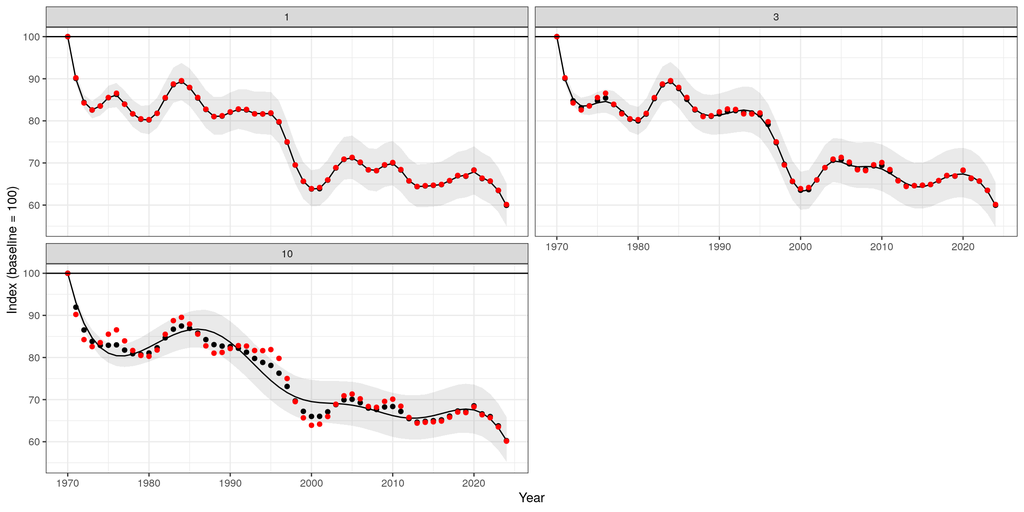

```r
gp0 <- ggplot(data = subset(df, group=="all"), aes(x=Year)) +
  geom_ribbon(aes(ymin=lowerCI.M, ymax=upperCI.M), alpha = 0.1) +
  geom_line(aes(y=Index.M)) +
  geom_point(aes(y=Index.Mprime)) +
  geom_point(aes(y=unsmoothedMSI), col="red") +
  facet_wrap(~ypk, nrow=2) +
  geom_hline(yintercept = 100) +
  ylab("Index (baseline = 100)") +
  theme_bw()
gp0
```

Each panel here represents a different degree of smoothing. In all cases, smoothing on the log scale means that the long term trend is for a larger decline (than smoothing on the measurement scale)

The red dots here are from the WBI method for calculating the geometric mean. It’s the same data plotted in all the panels. We would expect this to map on very closely to the 1 year per knot example.

## By taxon

Plot separately for each taxon.

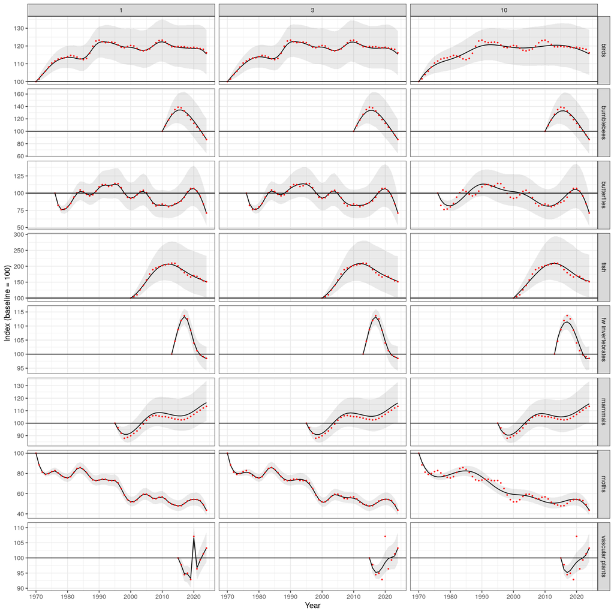

```r
gp1 <- ggplot(data = df, aes(x=Year)) +
  geom_ribbon(aes(ymin=lowerCI.M, ymax=upperCI.M), alpha = 0.1) +
  geom_line(aes(y=Index.M)) +
  geom_point(aes(y=unsmoothedMSI), col="red", size = .4) +
  facet_grid(group~ypk, scales = "free_y") +
  ylab("Index (baseline = 100)") +
  theme_bw()

gp1  %+% subset(df, !group %in% c("all", "all_five_yr", "all_ten_yr")) +
geom_hline(yintercept = 100)
```

You can really see the effect of changing the number of knots on the moth trend.

Zoom into the period since 2000 (including the “all” groups now)

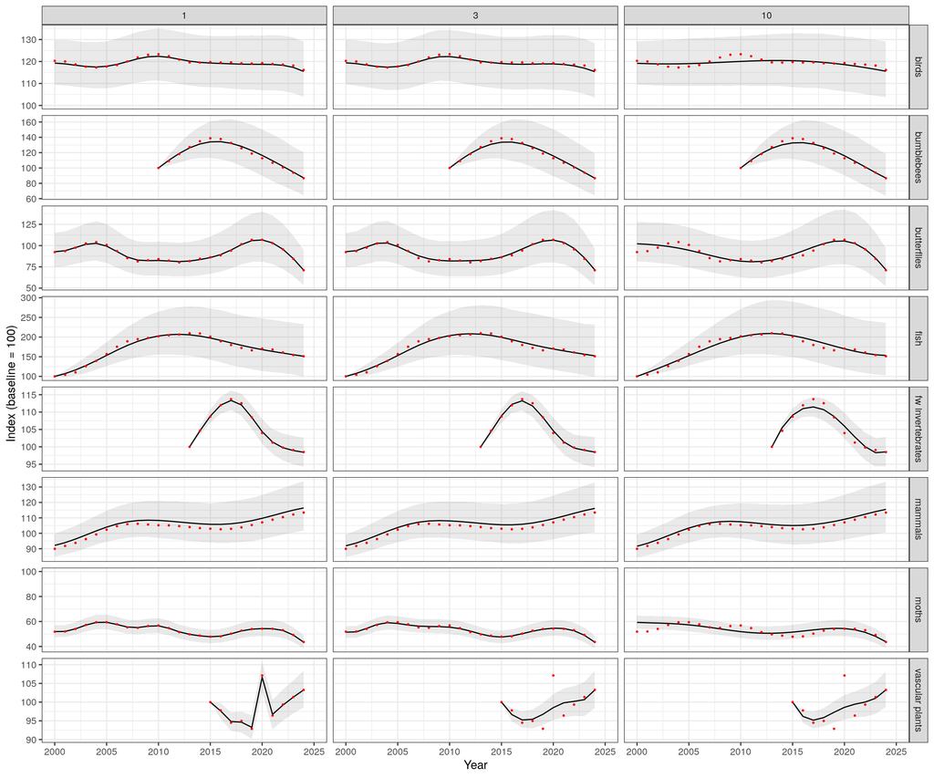

```r
minYr <- 2000
gp1  %+% subset(df, !group %in% c("all_five_yr", "all_ten_yr", "all")) +
  xlim(c(minYr, 2025))
```

In these plots, the uncertainty is expressed relative to the baseline (1970 for some groups). I could re-calculate the uncertainty ribbons so that they’re measuring change relative to this new baseline.

plot re-baselined all species 3ypk

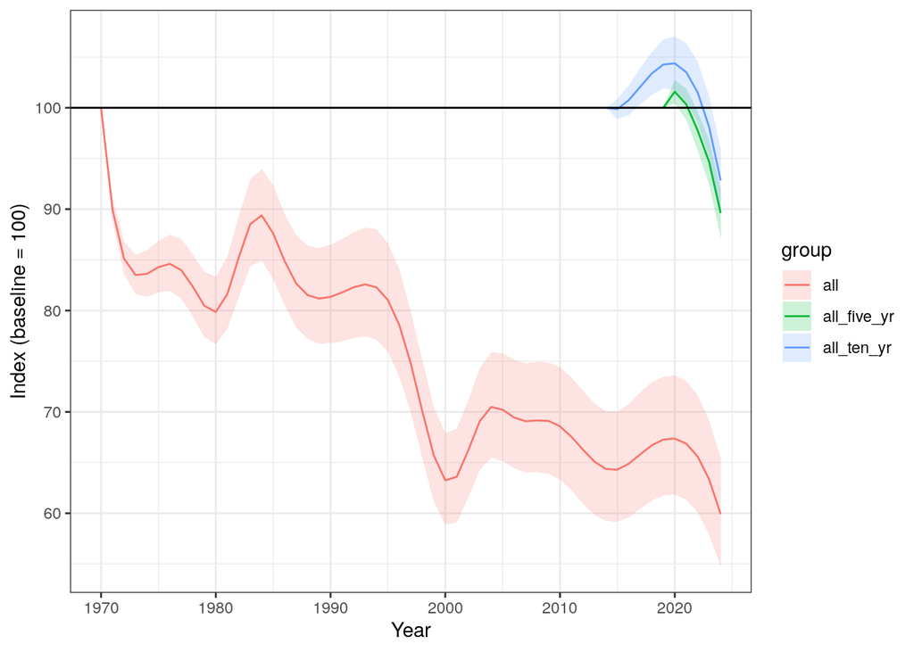

```r
ggplot(data = subset(df, group %in% c("all", "all_five_yr", "all_ten_yr") & ypk == 3), aes(x=Year)) +
  geom_ribbon(aes(ymin = lowerCI.M, ymax = upperCI.M, fill = group), alpha = 0.2 ) +
  geom_line(aes(y = Index.M, col = group)) +
  geom_hline(yintercept = 100) +
  ylab("Index (baseline = 100)") +
  scale_x_continuous(breaks = breaks_pretty()) +
  theme_bw()
```

rescale to final year to make comparison easier and look post 2010

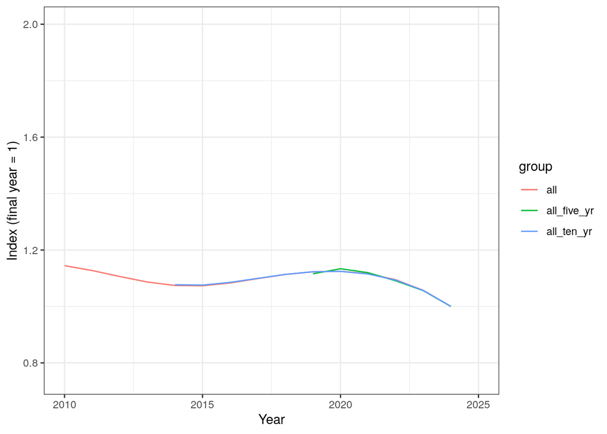

```r
rb <- df %>%
  filter(group == "all" & ypk == 3| group ==  "all_five_yr"| group == "all_ten_yr" ) %>%
  group_by(group) %>%
  mutate(rel_final = Index.M/Index.M[Year == 2024])

ggplot(rb, aes(x=Year)) +
  geom_line(aes(y = rel_final, col = group)) +
  ylab("Index (final year = 1)") +
  scale_y_continuous( limits = c(.75, 2)) +
  theme_bw() +
  xlim(2010, 2025)
```

Differences between the different numbers of knots are not especially clear.

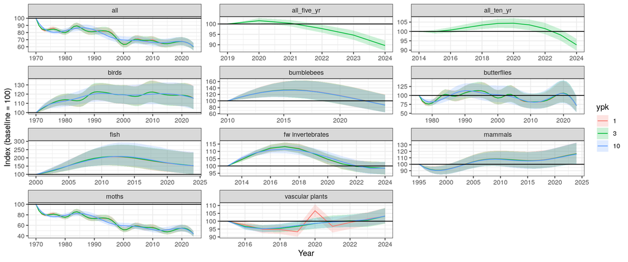

For most groups, the choice of smoothing makes very little difference. There is an observable effect for plants, moths and butterflies.

Now overlay the different Mprime (unsmoothed indicator) lines

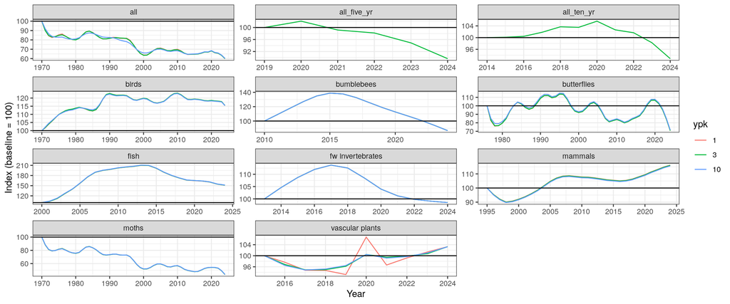

This shows that the “unsmoothed” line (M.prime) is almost completely insensitive to the number of knots. This is particularly true for the taxon-specific trends, but less true of the all-species plot and plants.

## Official plot

Defra has decided that the preferred option is to present the `ypk = c(10, 3)` lines on the same plot, with `ypk = 1` as points representing the unsmoothed trend.

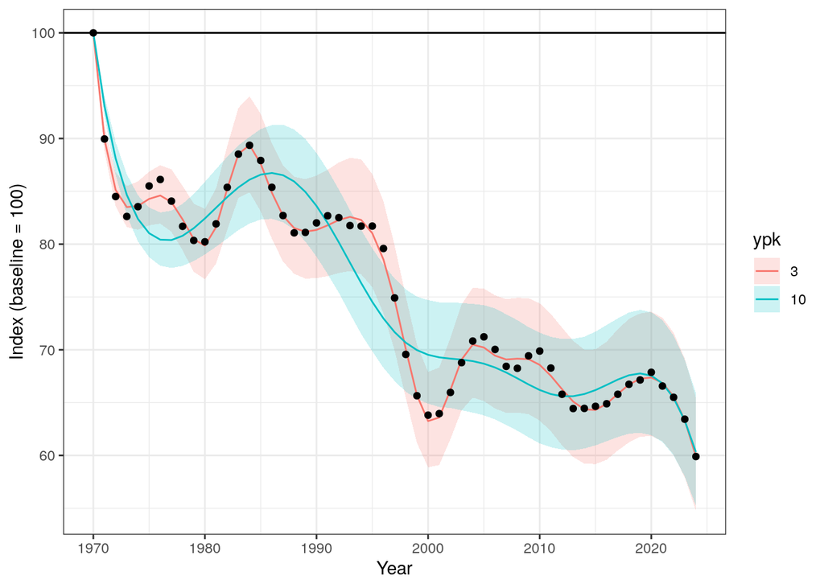

```r
prodplotAll <- ggplot(data = subset(df, group %in% c("all") & ypk %in% c(3, 10)),
                      aes(x=Year)) +
  geom_ribbon(aes(ymin=lowerCI.M, ymax=upperCI.M, fill=ypk), alpha = 0.2) +
  geom_line(aes(y=Index.M, col=ypk)) +
  geom_point(data = subset(df, group %in% c("all") & ypk == 1),
             aes(x=Year, y=Index.M), col = "black") +
  geom_hline(yintercept = 100) +
  ylab("Index (baseline = 100)") +
  scale_x_continuous(breaks = breaks_pretty()) +
  theme_bw()
prodplotAll
```

The unsmoothed (1 knot per year) line is almost identical to the 3 years-per-knot line.

Now for each taxonomic group

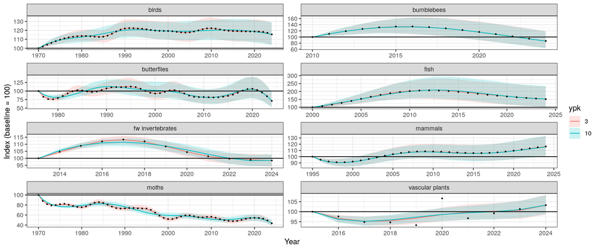

```r
prodplotTx <- ggplot(data = subset(df, !group %in% c("all", "all_five_yr", "all_ten_yr") & ypk %in% c(3, 10)),
                      aes(x=Year)) +
  geom_ribbon(aes(ymin=lowerCI.M, ymax=upperCI.M, fill=ypk), alpha = 0.2) +
  geom_line(aes(y=Index.M, col=ypk)) +
  geom_point(data = subset(df, !group %in% c("all") & ypk == 1),
             aes(x=Year, y=Index.M), col = "black", size = .5) +
  geom_hline(yintercept = 100) +
  ylab("Index (baseline = 100)") +
  scale_x_continuous(breaks = breaks_pretty()) +
  theme_bw()

prodplotTx + facet_wrap(~group, nrow=4, scales = "free")
```

We can see that the unsmoothed index is almost identical to the 3 years per knot line.

NB several time-series don’t quite have enough data for 10 years per knot.

- Bumblebees have 15 years of data, so we would really need one more year for a second knot, according to the rules we set.
- Freshwater invertebrates have only 12 years of data; vascular plants ten.
- In these cases the number of knots is two. This corresponds to 7.5 ypk for bumblebees, 6 ypk for FWI and 5 ypk for plants. We need to capture this in the indicator documents.

# Change metrics

Now summarise the long-term, short-term and instantaneous change for each version of the index.

## Long term

The long term trend is the same, regardless of the number of knots. Let’s report these as % change since the baseline.

```r
sf <- 3
LongTerm <- subset(df, ypk == 10, select = !grepl("prime", names(df))) %>%
  group_by(group) %>%
  filter(Year == max(Year)) %>%
  mutate(Index.M = signif(Index.M - 100, sf),
         lowerCI.M = signif(lowerCI.M - 100, sf),
         upperCI.M = signif(upperCI.M - 100, sf)) %>%
  dplyr::rename(BestEst = Index.M,
                lowerCI = lowerCI.M,
                upperCI = upperCI.M)

LongTerm[,c(6,5,2:4)]
```

```
## # A tibble: 9 × 5
## # Groups:   group [9]
##   ypk   upperCI group            BestEst lowerCI
##   <fct>   <dbl> <chr>              <dbl>   <dbl>
## 1 10     -34.1  all               -39.7  -44.7
## 2 10      29.1  birds              15.6    3.77
## 3 10      18.2  bumblebees        -13.1  -36.4
## 4 10      -2.96 butterflies       -28.4  -48
## 5 10     136    fish               53.1    2.57
## 6 10       2.82 fw invertebrates   -1.45  -5.62
## 7 10      33.5  mammals            15.5    0.488
## 8 10     -50.5  moths             -56.3  -61.2
## 9 10       8.18 vascular plants     3.28  -1.24
```

The lower and upper CI represent the 95% credible intervals. This means we are 95% confident that the true value lies within this range.

## Short Term assessment

```r
TimeboundChange <- function(x, metric="ind", t=5){
  temp <- subset(df, group == x["group"][[1]] & ypk == as.numeric(x["ypk"][[1]]))
  Y1 <- max(temp$Year, na.rm=TRUE)
  Y0 <- Y1 - t
  temp2 <- subset(temp, Year %in% c(Y0, Y1))
  stat <- diff(temp2$Index.M)
  if(metric == "pc"){ # convert to a percentage
    stat <- 100 * stat / temp2[temp2$Year==Y0,"Index.M"]
  }
  round(stat,1)
}

tempch <- apply(pars, 1, TimeboundChange, metric="ind", t=5)
ShortTerm1 <- cbind(pars[c(1,2,5)], change=tempch)
(ShortTerm1 <- acast(ShortTerm1, group~ypk, value.var="change"))
```

```
##                      1     3    10
## all               -7.2  -7.4  -7.4
## all_five_yr         NA -10.4    NA
## all_ten_yr          NA -11.4    NA
## birds             -3.2  -3.5  -3.6
## bumblebees       -35.7 -35.3 -35.5
## butterflies      -34.7 -33.8 -33.5
## fish             -22.1 -22.6 -24.0
## fw invertebrates -10.0 -10.0 -10.2
## mammals            8.3   8.3   7.9
## moths            -10.4 -10.4 -10.8
## vascular plants   10.0   6.5   6.0
```

Each column represents a different degree of smoothing (number of knots per year). Note that, when pre-smoothing happens on the log scale, there is very little variation in the 5 year trend. When smoothed on the measurement scale, the magnitude of change varies by 100% for moths and butterflies.

Values in this table are relative to the baseline conditions in the first year. Let’s repeat these calculations but calculate change as a percentage of the value five years ago.

```r
change <- apply(pars, 1, TimeboundChange, metric="pc", t=5)
ShortTerm1 <- cbind(pars[c(1,2,5)], change=change)
(ShortTerm1 <- acast(ShortTerm1, group~ypk, value.var="change"))
```

```
##                      1     3    10
## all              -10.8 -10.9 -11.0
## all_five_yr         NA -10.4    NA
## all_ten_yr          NA -11.0    NA
## birds             -2.7  -2.9  -3.0
## bumblebees       -29.1 -28.9 -29.0
## butterflies      -32.8 -32.1 -31.9
## fish             -12.7 -12.9 -13.5
## fw invertebrates  -9.2  -9.2  -9.4
## mammals            7.6   7.7   7.3
## moths            -19.4 -19.3 -19.8
## vascular plants   10.7   6.7   6.2
```

## Final year change

Finally, let’s look at the value of the first derivative in the final year. Again, we’ll express this as a percentage of the previous year’s value.

```r
finalYrChange <- function(mod){
    modsum <- attr(mod, "model")$summary
    logLam <- modsum[grepl("logLambda", dimnames(modsum)[[1]]),]
    ll <- logLam[nrow(logLam),c(1,3,7,11)]
    ll[1:3] <- 100 * (exp(ll[1:3]) - 1)
    signif(ll, 2)
}

# log scale pre-smoothing
FinalYr <- t(sapply(output, finalYrChange))
(FinalYr <- cbind(pars[,c(1,2,3)], FinalYr))
```

```
##                                                     group ypk n.knots   mean
## all_10ypk_L_5kit_260313.rds                           all  10       6  -4.70
## all_1ypk_L_5kit_260313.rds                            all   1      55  -5.60
## all_3ypk_L_5kit_260313.rds                            all   3      18  -5.40
## all_3ypk_L_d4_five_yr_5kit_260313.rds         all_five_yr   3       2  -5.30
## all_3ypk_L_d4_ten_yr_5kit_260313.rds           all_ten_yr   3       4  -5.30
## birds_10ypk_L_5kit_260313.rds                       birds  10       6  -0.74
## birds_1ypk_L_5kit_260313.rds                        birds   1      55  -1.60
## birds_3ypk_L_5kit_260313.rds                        birds   3      18  -1.30
## bumblebees_10ypk_L_5kit_260313.rds             bumblebees  10       2  -7.50
## bumblebees_1ypk_L_5kit_260313.rds              bumblebees   1      15  -8.00
## bumblebees_3ypk_L_5kit_260313.rds              bumblebees   3       5  -7.90
## butterflies_10ypk_L_5kit_260313.rds           butterflies  10       5 -16.00
## butterflies_1ypk_L_5kit_260313.rds            butterflies   1      49 -16.00
## butterflies_3ypk_L_5kit_260313.rds            butterflies   3      16 -17.00
## fish_10ypk_L_5kit_260313.rds                         fish  10       2  -1.20
## fish_1ypk_L_5kit_260313.rds                          fish   1      25  -2.60
## fish_3ypk_L_5kit_260313.rds                          fish   3       8  -2.60
## fw invertebrates_10ypk_L_5kit_260313.rds fw invertebrates  10       2   0.24
## fw invertebrates_1ypk_L_5kit_260313.rds  fw invertebrates   1      12  -0.51
## fw invertebrates_3ypk_L_5kit_260313.rds  fw invertebrates   3       4  -0.52
## mammals_10ypk_L_5kit_260313.rds                   mammals  10       3   1.30
## mammals_1ypk_L_5kit_260313.rds                    mammals   1      30   1.20
## mammals_3ypk_L_5kit_260313.rds                    mammals   3      10   1.30
## moths_10ypk_L_5kit_260313.rds                       moths  10       6  -9.10
## moths_1ypk_L_5kit_260313.rds                        moths   1      55 -12.00
## moths_3ypk_L_5kit_260313.rds                        moths   3      18 -11.00
## vascular plants_10ypk_L_5kit_260313.rds   vascular plants  10       2   2.20
## vascular plants_1ypk_L_5kit_260313.rds    vascular plants   1      10   1.90
## vascular plants_3ypk_L_5kit_260313.rds    vascular plants   3       3   2.60
##                                             2.5%  97.5%    f
## all_10ypk_L_5kit_260313.rds               -5.300  -4.00 1.00
## all_1ypk_L_5kit_260313.rds                -6.400  -4.70 1.00
## all_3ypk_L_5kit_260313.rds                -6.200  -4.60 1.00
## all_3ypk_L_d4_five_yr_5kit_260313.rds     -6.400  -4.20 1.00
## all_3ypk_L_d4_ten_yr_5kit_260313.rds      -6.200  -4.50 1.00
## birds_10ypk_L_5kit_260313.rds             -1.700   0.26 0.93
## birds_1ypk_L_5kit_260313.rds              -2.800  -0.36 0.99
## birds_3ypk_L_5kit_260313.rds              -2.400  -0.24 0.99
## bumblebees_10ypk_L_5kit_260313.rds       -13.000  -1.50 0.99
## bumblebees_1ypk_L_5kit_260313.rds        -13.000  -2.10 0.99
## bumblebees_3ypk_L_5kit_260313.rds        -13.000  -1.90 0.99
## butterflies_10ypk_L_5kit_260313.rds      -19.000 -13.00 1.00
## butterflies_1ypk_L_5kit_260313.rds       -19.000 -13.00 1.00
## butterflies_3ypk_L_5kit_260313.rds       -19.000 -14.00 1.00
## fish_10ypk_L_5kit_260313.rds              -6.800   4.70 0.64
## fish_1ypk_L_5kit_260313.rds               -8.600   3.10 0.79
## fish_3ypk_L_5kit_260313.rds               -8.400   3.60 0.81
## fw invertebrates_10ypk_L_5kit_260313.rds  -0.930   1.40 0.65
## fw invertebrates_1ypk_L_5kit_260313.rds   -1.800   0.77 0.77
## fw invertebrates_3ypk_L_5kit_260313.rds   -1.800   0.72 0.79
## mammals_10ypk_L_5kit_260313.rds           -0.410   3.00 0.93
## mammals_1ypk_L_5kit_260313.rds            -0.620   3.20 0.91
## mammals_3ypk_L_5kit_260313.rds            -0.560   3.10 0.92
## moths_10ypk_L_5kit_260313.rds            -10.000  -8.00 1.00
## moths_1ypk_L_5kit_260313.rds             -13.000 -10.00 1.00
## moths_3ypk_L_5kit_260313.rds             -13.000 -10.00 1.00
## vascular plants_10ypk_L_5kit_260313.rds    0.054   4.70 0.98
## vascular plants_1ypk_L_5kit_260313.rds    -0.680   4.50 0.92
## vascular plants_3ypk_L_5kit_260313.rds    -0.012   5.70 0.97
```

The `f` column indicates the proportion of the posterior distribution that is the same sign as the mean, i.e. our confidence in the direction of the trend. Values close to 1 indicate high confidence; values close to 0.5 (the minimum) indicate low confidence in a change. Note that, in most cases, our estimates are quite confident (i.e. `f > 0.8`), meaning that we reject the “no change” category.

### Summary of final year

- For “all” there is a decline of 4.7 to 5.6%pa for three of the smoothed options.

# Species-level trends

We first need to identify the two “all species” runs

```r
#we need to filter out the re-based model outputs
output     <- output[-grep("_yr", names(output))]
#need to remove re-based models for this to work properly
modelfiles <- modelfiles[-grep("_yr", modelfiles)]
```

```r
getSpTrends <- function(name, n = 0){
  # `n` is an optional variable determining the number of years over which to estimate the trend
  # if zero then the full series is used. If an integer above zero then the final `n` years of the series is used
  mod <- attr(output[[grep(name, modelfiles)]], "model")
  spg <- mod$mean$spgrowth
  estimate <- mod$data$estimate # the raw data. Has one more column than spg

  if(n > 0){
    # short term assessment. Restrict spg to the last n years
    N <- dim(spg)[2]
    spg <- spg[,(N-n):N]
    estimate <- estimate[,(N-n):N]
  } else {
    estimate <- estimate[,-1]
  }

  spMGR <- sapply(1:nrow(spg), function(i){
    rates <- spg[i,!is.na(estimate[i,])]
    mean(rates[-1]) # ignore first value - this is the first year with data so the GR is from other species
  })

  names(spMGR) <- dimnames(estimate)[[1]]
  100*(exp(spMGR)-1)
}

spTrends <- lapply(c(0,5), function(n){
  x<-as.data.frame(do.call(cbind, lapply(list("all_3", "all_10"), getSpTrends, n=n)))
  names(x) <- paste0(c("ypk3", "ypk10"), "_",n)
  x
})
spTrends <- do.call(cbind, spTrends)
head(spTrends)
```

```
##                            ypk3_0     ypk10_0     ypk3_5    ypk10_5
## abramis brama          -5.2939308  -5.2922850   3.407990   3.398669
## abraxas grossulariata  -1.3476931  -1.3478683   5.172663   5.170344
## abraxas sylvata       -11.2498160 -11.2499053 -20.276934 -20.274693
## abrostola tripartita    0.8910717   0.8907649   7.975892   7.977690
## abrostola triplasia     2.4445079   2.4444841  34.457249  34.462694
## acanthis cabaret       -5.8394631  -5.8703762  -1.435643  -1.485645
```

The `ypk3_0` column is the long term trend when smoothed with three knots per year. The `ypk10_5` column is the short term trend (last 5 years) when smoothed with ten knots per year. etc etc. All trends are measured as the mean across years, converted to a percentage increase/decrease in abundance

Take a look at the overall distribution

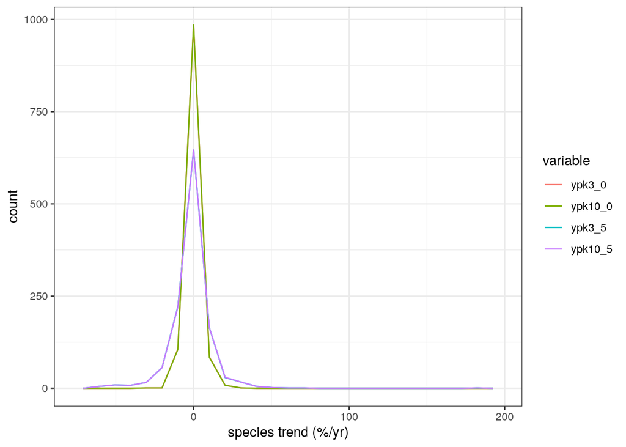

```r
ggplot(data=melt(spTrends)) +
  geom_freqpoly(aes(value, col=variable), bins = 25) +
  xlab("species trend (%/yr)") +
  theme_bw()
```

Some very large values! Let’s look at the quantiles.

```r
pc <-  c(1,5,10,25)
signif(apply(spTrends, 2, quantile, c(pc/100,0.5,sort(1-pc/100)), na.rm=T),2)
```

```
##     ypk3_0 ypk10_0 ypk3_5 ypk10_5
## 1%  -11.00  -11.00 -49.00  -49.00
## 5%   -6.70   -6.70 -20.00  -20.00
## 10%  -4.70   -4.80 -13.00  -13.00
## 25%  -2.30   -2.30  -5.50   -5.50
## 50%  -0.43   -0.44  -0.72   -0.68
## 75%   1.60    1.60   3.60    3.60
## 90%   4.10    4.10   9.60    9.60
## 95%   6.70    6.60  15.00   15.00
## 99%  13.00   13.00  33.00   33.00
```

We need to include the `na.rm=T` because there is a small number of species with no data in the last 5 years

This clearly shows that most species trends are within the range of what we would expect. The short-term trends are absolutely larger than the long-term: again this is what we expect (short term trends are subject to noisy fluctuation).

## Extreme species trends

Take a look at the raw data for the most steeply declining species

```r
losers <- subset(spTrends, ypk3_0 < -11)
losers
```

```
##                           ypk3_0   ypk10_0     ypk3_5    ypk10_5
## abraxas sylvata        -11.24982 -11.24991 -20.276934 -20.274693
## bombus campestris      -11.21582 -11.21633   2.244785   2.238845
## dioscorea communis     -14.70347 -14.70356  -3.608756  -3.609897
## haliplus confinis      -27.16642 -27.16557 -49.235022 -49.233093
## hordeum secalinum      -11.01926 -11.01895  -8.439887  -8.439718
## limnephilus extricatus -13.85623 -13.85508 -13.233994 -13.230146
## notonecta viridis      -20.58176 -20.58097 -29.759385 -29.757892
## orthonama vittata      -11.18921 -11.18951 -40.350655 -40.352660
## osmerus eperlanus      -14.32649 -14.29259 -22.992494 -23.309246
## rhyacophila fasciata   -14.61684 -14.61704 -28.148644 -28.148712
```

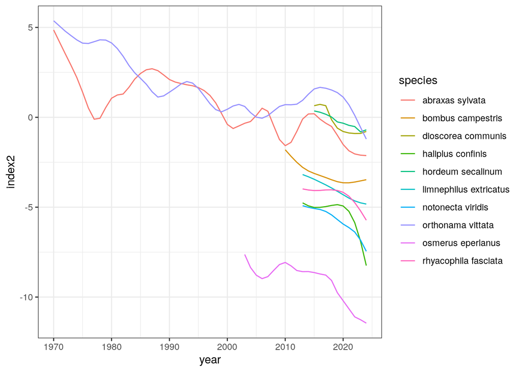

```r
ggplot(data = subset(data1, species %in% rownames(losers)),
       aes(x=year, y=index2, col=species)) +
    geom_line() +
  theme_bw()
```

- Moths
  - Abraxas sylavata - clouded magpie zeros in many recent years
  - Orthonama vittata- oblique carpet zeros in some recent years
- Bumblebee - Bombus campestris
- Fw invert
  - Halipius confinis zero in 2024
  - Lmnephilus extricatus
  - Notonecta viridis
  - Rhyacophilia fasciata
- Plants
  - Dioscorea communis aka tamus communis
  - Hordeum secalinum
- Fish
  - Osmerus eperianus smelt

And the steepest increases

```r
winners <- subset(spTrends, ypk3_0 > +13)
winners
```

```
##                             ypk3_0  ypk10_0     ypk3_5    ypk10_5
## ammodytes tobianus        14.56774 14.57030  -4.854116  -4.774881
## bombus lucorum/terrestris 20.23226 20.23169  -2.094372  -2.097246
## clupea harengus           29.37162 29.36352 -17.407975 -17.393143
## cobitis taenia            18.55849 18.56302  -5.735778  -5.760024
## dryops spp.               16.69366 16.69332  17.413498  17.414399
## liza ramada               13.33324 13.37661  48.333304  48.224920
## maculinea arion           14.50918 14.50910  -1.059801  -1.057092
## milvus milvus             13.74522 13.71113   8.654716   8.794744
## mythimna albipuncta       18.16224 18.16182  18.188364  18.185134
## nigrobaetis spp.          17.82419 17.82407  21.756489  21.754790
## platalea leucorodia       21.48100 21.48059  15.098766  15.238590
## pomatoschistus microps    20.45679 20.41951  -6.732537  -6.723130
## potamanthus luteus        17.70547 17.70548  29.347601  29.347437
```

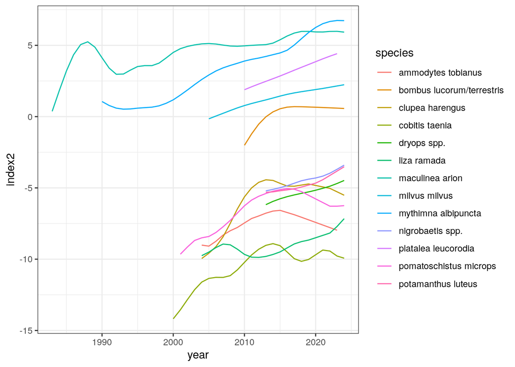

```r
ggplot(data = subset(data1, species %in% rownames(winners)),
       aes(x=year, y=index2, col=species)) +
    geom_line() +
  theme_bw()
```

- Fish
  - Ammodytes tobianus - lesser sandeel! very sparse data in recent years, smoothed trend looks odd
- Other species trends seem to reflect underlying data
  - Clupea harengus - herring
  - Liza ramada - thin lipped grey mullet
  - Cobitis taenia - spined loach
  - Pomatoschistus microps - common goby
- Bumblebees: Bombus lucorum/terrestris
- Moth: Mythiman ablipuncta - white-point
- FW inv: Dryops spp., Nigrobaeis spp, Potamanthus luteus
- Bird: Milvus milvus - Red Kite (reinforcement), Platalea leucorodia - spoonbill (coloniser)
- Butterfly: Maculinea arion - Large Blue, reintroduced, rapid recovery

## Categories of change

Get the group identity and summarise into categories and report the values for each group

```r
spTrends$group <- data1$group[match(rownames(spTrends), data1$species)]
spTrends$survey <- data1$survey[match(rownames(spTrends), data1$species)]

spTrends$longTrendCat <- cut(spTrends$ypk3_0,
                         breaks = c(-Inf, -2.73, -1.14, +1.16, +2.81, Inf),
                         labels = c("Strong decrease", "Weak decrease", "Little change", "Weak increase", "Strong increase"))
summary(spTrends$longTrendCat)
```

```
## Strong decrease   Weak decrease   Little change   Weak increase Strong increase
##             260             225             345             170             185
```

```r
spTrends$shortTrendCat <- cut(spTrends$ypk3_5,
                         breaks = c(-Inf, -2.73, -1.14, +1.16, +2.81, Inf),
                         labels = c("Strong decrease", "Weak decrease", "Little change", "Weak increase", "Strong increase"))
summary(spTrends$shortTrendCat)
```

```
## Strong decrease   Weak decrease   Little change   Weak increase Strong increase
##             455             103             180             108             335
##            NA's
##               4
```

```r
with(spTrends, table(group, longTrendCat))
```

```
##                   longTrendCat
## group              Strong decrease Weak decrease Little change Weak increase
##   birds                         24            30            54            29
##   bumblebees                     5             0             3             0
##   butterflies                   10            14            19             7
##   fish                          12             4             6             2
##   fw invertebrates              57            47            44            30
##   mammals                        4             0             6             2
##   moths                        118           112           125            53
##   vascular plants               30            18            88            47
##                   longTrendCat
## group              Strong increase
##   birds                         31
##   bumblebees                     3
##   butterflies                    5
##   fish                          13
##   fw invertebrates              57
##   mammals                        5
##   moths                         36
##   vascular plants               35
```

```r
with(spTrends, table(group, shortTrendCat))
```

```
##                   shortTrendCat
## group              Strong decrease Weak decrease Little change Weak increase
##   birds                         57            24            35            12
##   bumblebees                     7             1             2             1
##   butterflies                   39             4             1             4
##   fish                          19             1             3             0
##   fw invertebrates             104            26            30            21
##   mammals                        2             2             6             3
##   moths                        197            25            43            39
##   vascular plants               30            20            60            28
##                   shortTrendCat
## group              Strong increase
##   birds                         37
##   bumblebees                     0
##   butterflies                    7
##   fish                          14
##   fw invertebrates              54
##   mammals                        4
##   moths                        139
##   vascular plants               80
```

```r
write.csv(spTrends, file = file.path(modeldir,"spTrends_allspp_to2024_130326.csv")) # unsm VP cat chg
```

Summarise species trends - based on categorisation of change from knots per 3 year model

```r
spTrend_grp <- spTrends %>%
  select(group, longTrendCat, shortTrendCat) %>%
  melt(id.vars = "group") %>%
  group_by(group, variable, value) %>%
  summarise(n_spp = n()) %>%
  group_by(group, variable) %>%
  mutate(pct_spp = n_spp/sum(n_spp[!is.na(value)]))
spTrend_sum <- spTrends %>%
  select(group, longTrendCat, shortTrendCat) %>%
  melt(id.vars = "group") %>%
  group_by(variable, value) %>%
  summarise(n_spp = n()) %>%
  group_by(variable) %>%
  mutate(pct_spp = n_spp/sum(n_spp[!is.na(value)]),
         group = "all") %>%
  full_join(spTrend_grp) %>%
  rename(period = variable, trend_category = value) %>%
  mutate(trend_category =
           factor(trend_category,
                  levels = c("Strong decrease", "Weak decrease", "Little change",
                             "Weak increase", "Strong increase"))) %>%
  arrange(group, period, trend_category)
write.csv(spTrend_sum, file = file.path(modeldir, "spTrends_allspp_to2024_summary130326.csv"), row.names = FALSE)
```